# Parallel backends for tidymodels workloads

Benchmarks of future, mirai, and mizu on four real modeling tasks — DRAFT

**WarningDraft report**

This is a working draft. Results, figures, and conclusions are preliminary and have not been reviewed. Do not cite or distribute as a final report.

## Overview

Resampling is the expensive part of most modeling work. A bootstrap or cross-validation run fits the same model hundreds of times. On one core this takes minutes or hours. Parallel workers cut this to a fraction of the time.

Several backends can supply those workers, and they are not equally fast. This report compares three of them — **future**, **mirai**, and **mizu** — on four modeling workloads built from tidymodels packages. The workloads are common modeling tasks: bootstrap confidence intervals, resampled model fits, permutation importance, and bootstrap prediction intervals. They also move increasing amounts of data between the main session and the workers, which is where the backends differ most.

Every workload also runs sequentially, as a baseline and as a correctness reference: each backend must return results identical to the sequential run.[^1] All runs use 12 workers on a 14-core Apple Silicon Mac (R 4.6.1 (2026-06-24)).

## The workloads

Each workload is a standard modeling task, sized so that a sequential run takes a few minutes:

- **A: Bootstrap metrics.** Compute bootstrap confidence intervals for the performance of a regression model: score 5,000 bootstrap splits with four yardstick metrics (`rmse`, `rsq`, `mae`, `ccc`).
- **B: Resampled model fits.** The same pattern as `fit_resamples()`: fit a workflow (a recipe plus logistic regression) on 250 bootstrap resamples, and score each fit on its held-out rows.
- **C: Permutation importance.** Measure how much each predictor matters to a fitted model. On 240 bootstrap replicates of a validation set, permute each of the 30 predictors in turn and record the drop in AUC.
- **D: Bootstrap prediction intervals.** Quantify the uncertainty of expected losses for a book of insurance policies. Each task refits a Gamma severity model on one of 400 bootstrap splits and scores all 250,000 policies.

| Workload | What it represents | Tasks | Per-task cost | Per-task input | Shared input (constant) | Per-task result |
| --- | --- | --- | --- | --- | --- | --- |
| A: Bootstrap metrics | bootstrap confidence intervals with yardstick metric sets | 5000 | ~3 ms | 1 bootstrap split (~200 KB) | — | 4-row tibble |
| B: Resampled model fits | fit_resamples() on a parsnip workflow (recipe + logistic regression) | 250 | ~45 ms | 1 bootstrap split (~1.7 MB) | — | 2-row tibble |
| C: Permutation importance | bootstrap permutation importance: 240 replicates, each permuting all 30 predictors in turn | 240 | ~85 ms | 1 bootstrap replicate (~2.8 MB) | fitted glm (0.2 MB) | 30-row tibble |
| D: Bootstrap prediction intervals | bootstrap prediction intervals: refit a Gamma severity model, score the whole portfolio | 400 | ~90 ms | 1 bootstrap split (~3.4 MB) | 38 MB portfolio (250k policies) | 250k-length numeric (2 MB) |

The workloads grow heavier in data terms from A to D: larger per-task inputs, then a large shared input, then large per-task results. Each task function loads its own packages with `require()`, so every backend pays the same worker setup cost.[^2]

**NoteThe exact task functions**

```r
# A: yardstick metrics on one bootstrap split
task_metrics <- function(split) {
  require(rsample)
  require(yardstick)
  mtr <- metric_set(rmse, rsq, mae, ccc)
  mtr(analysis(split), y, .pred)
}

# B: parsnip workflow fit on the analysis set, scored out-of-bag
task_fit_glm <- function(split) {
  require(rsample); require(recipes); require(parsnip)
  require(workflows); require(yardstick); require(dplyr)
  wf <- workflow() |>
    add_recipe(recipe(class ~ ., data = analysis(split)) |>
                 step_normalize(all_numeric_predictors())) |>
    add_model(logistic_reg() |> set_engine("glm"))
  fitted <- fit(wf, data = analysis(split))
  assess <- assessment(split)
  pred <- predict(fitted, assess, type = "prob") |>
    bind_cols(predict(fitted, assess, type = "class")) |>
    bind_cols(assess |> select(class))
  bind_rows(roc_auc(pred, class, .pred_yes),
            accuracy(pred, class, .pred_class))
}

# C: one bootstrap replicate of the validation set; permute each
# predictor in turn and record the AUC drop against the pre-fit model
task_permimp <- function(task, model) {
  require(rsample); require(yardstick); require(dplyr)
  set.seed(task$seed, kind = "Mersenne-Twister")
  dat <- analysis(task$split)
  truth <- dat$y
  pred <- as.numeric(predict(model, newdata = dat, type = "response"))
  base_auc <- roc_auc_vec(truth, pred, event_level = "second")
  cols <- setdiff(colnames(dat), "y")
  importance <- numeric(length(cols))
  for (j in seq_along(cols)) {
    orig <- dat[[cols[j]]]
    dat[[cols[j]]] <- orig[sample.int(length(orig))]
    p <- as.numeric(predict(model, newdata = dat, type = "response"))
    importance[j] <- base_auc - roc_auc_vec(truth, p, event_level = "second")
    dat[[cols[j]]] <- orig
  }
  tibble(col = cols, base_auc = base_auc, importance = importance)
}

# D: refit the severity model on one bootstrap split and predict
# expected loss for every policy in the shared portfolio
task_bootpred <- function(split, portfolio) {
  require(rsample)
  fit <- glm(loss ~ ., data = analysis(split),
             family = Gamma(link = "log"), control = list(maxit = 25))
  as.numeric(predict(fit, newdata = portfolio, type = "response"))
}
```

## The three backends

All three backends run the same operation: apply a task function to every task, then collect the results. They differ in how data moves between the main R session and the workers.[^3]

- **future** (multisession, via future.apply) splits the task list into one chunk per worker and sends the chunks over sockets, one after another.
- **mirai** keeps a pool of persistent workers and streams tasks to them over sockets as they become free.
- **mizu** keeps a pool of workers that share memory with the main session. The inputs are written once, every worker reads the same copy, and the results come back through the same shared memory.[^4]

The worker pools are created once per backend, outside the timed region.[^5]

## Results

Every backend returned results identical to the sequential reference (`all.equal()` at 1e-8 tolerance) for all four workloads: all 13 backend × workload combinations match.

| Workload | Backend | Runs | Elapsed (s) | Speed-up | Efficiency (%) |
| --- | --- | --- | --- | --- | --- |
| A: Bootstrap metrics | mizu | 3 | 2.15 ± 0.02 | 6.67 | 56 |
| A: Bootstrap metrics | mirai | 3 | 8.10 ± 0.06 | 1.77 | 15 |
| A: Bootstrap metrics | future (multisession) | 3 | 24.62 ± 11.35 | 0.66 | 5 |
| B: Resampled model fits | mizu | 3 | 1.33 ± 0.03 | 7.87 | 66 |
| B: Resampled model fits | mirai | 3 | 2.65 ± 0.05 | 3.96 | 33 |
| B: Resampled model fits | future (multisession) | 3 | 5.46 ± 0.25 | 1.92 | 16 |
| C: Permutation importance | mizu | 3 | 2.53 ± 0.03 | 8.10 | 67 |
| C: Permutation importance | mirai | 3 | 3.20 ± 0.02 | 6.41 | 53 |
| C: Permutation importance | future (multisession) | 3 | 9.05 ± 0.22 | 2.27 | 19 |
| D: Bootstrap prediction intervals | mizu (stream) | 3 | 3.97 ± 0.12 | 7.57 | 63 |
| D: Bootstrap prediction intervals | mizu | 3 | 9.51 ± 0.17 | 3.16 | 26 |
| D: Bootstrap prediction intervals | mirai | 3 | 21.53 ± 0.73 | 1.40 | 12 |
| D: Bootstrap prediction intervals | future (multisession) | 3 | 72.00 ± 12.78 | 0.43 | 4 |

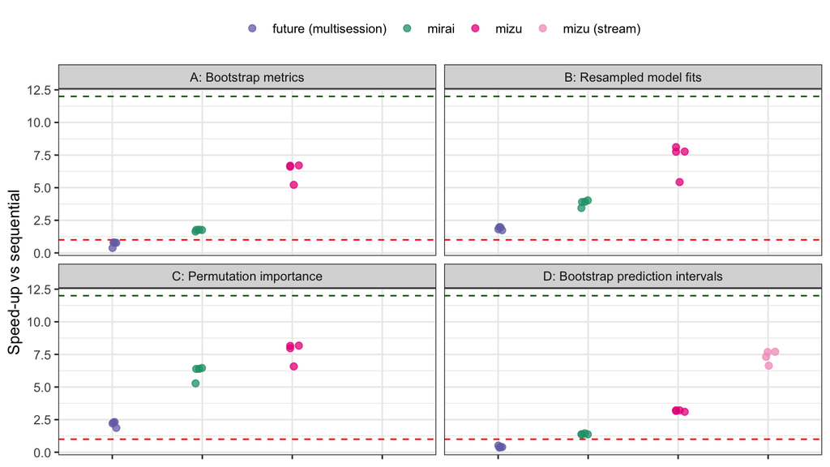

Each point is one run. The dashed lines mark no speed-up (red) and perfect scaling on 12 workers (green). The pattern is the same on all four workloads:

1. **mizu is the fastest backend everywhere**, in both of its configurations on workload D.
2. **mirai is second everywhere.**
3. **future falls further behind as tasks carry more data.** On workloads A and D it is slower than running sequentially.

## How well do the backends scale?

Adding workers helps only up to a point. Amdahl’s law says that the ceiling on the speed-up is set by the share of the work that stays serial.[^6] The figure below inverts the law at each measured 12-worker speed-up. Each curve passes through the mean of its measured points by construction, so the content of the plot is the shape: what more workers would buy if the serial share stayed constant.

**NoteAmdahl’s law reference curves**

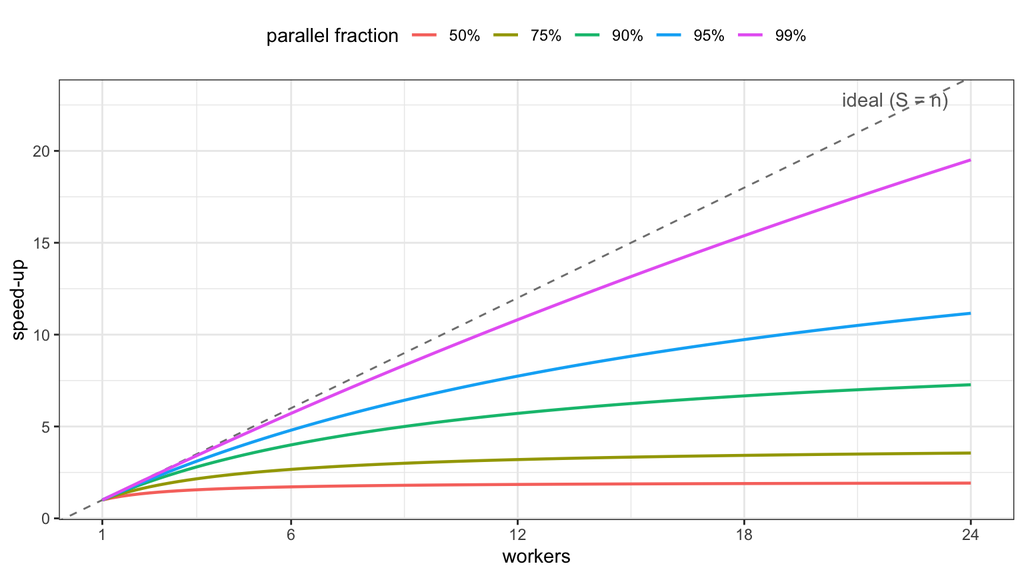

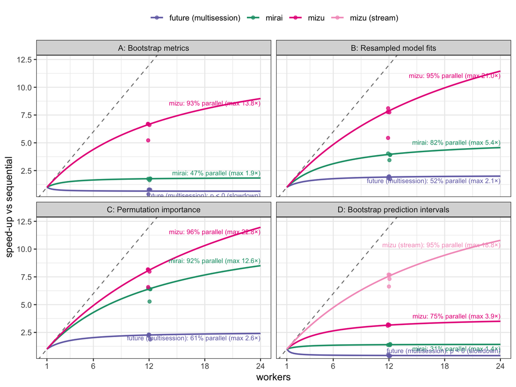

- **mizu** is still climbing at 12 workers on A, B, and C. The implied serial shares are 7% on A, 5% on B, and 4% on C.
- **mirai** is still climbing on C. On A and D it is at its ceiling, where per-task copying dominates.
- **future** speeds up by less than 1 on A and D, which the law cannot express. The model assumes a fixed serial share, but future’s dispatch overhead grows with the worker count (see CPU utilization). The flat curves there are a symptom of that overhead, not a prediction.

### Checking the fit with a worker sweep

The curves above are extrapolations from a single measurement at 12 workers. As a check, workloads B and C were re-run at 2, 4, and 8 workers per backend.[^7] The solid lines join the measured mean speed-ups. The dotted curves are the Amdahl predictions pinned at each backend’s 12-worker mean. Everything left of 12 is the model predicting runs it had not seen.

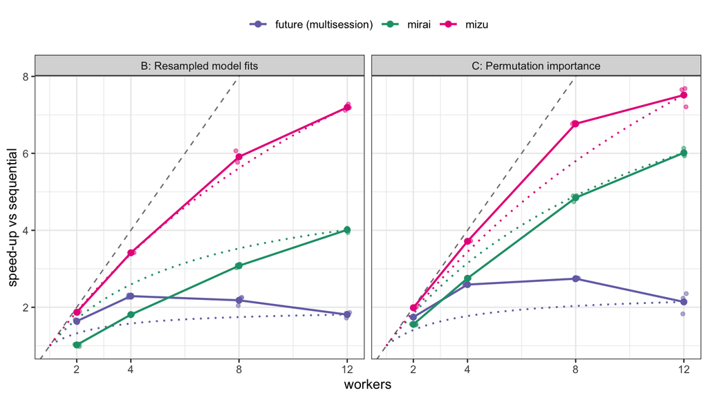

Every backend × worker count returned results identical to the sequential reference (all 24 combinations match).

If the law held exactly, the implied serial share would be the same at every worker count. Its drift across 2, 4, 8, and 12 workers is the diagnostic.[^8] Measured:

- **mizu** — near-flat: 6.9→6.1% on B, 0.6→5.4% on C. The measured points track the fitted curve closely, so mizu’s curves in the previous figure mean what they say.
- **mirai** — the share *falls* as workers increase (B: 96→18%, C: 29→9%). Per-task copying hurts most at 2 workers, where B barely speeds up at all (1.0×), and the cost amortizes as more workers join. The 12-pinned curve over-promises at 2–4 workers.
- **future** — the share *rises* with workers (B: 22→51%, C: 15→42%). The measured speed-up peaks at 4–8 workers (2.3–2.7×) and declines by 12, as the dispatch overhead costs more than the added workers return. future’s 12-worker runs are also the most variable in the benchmark: on C alone they span 1.8–2.4× (a 29% spread), where mirai and mizu stay within single digits.

The net: trust the fitted curves for mizu on both workloads, and for mirai on C from about 8 workers up. Everywhere else, the measured points, not the curves, are the scaling story.

## CPU utilization

The monitor recorded how many worker cores were busy through each monitored run:

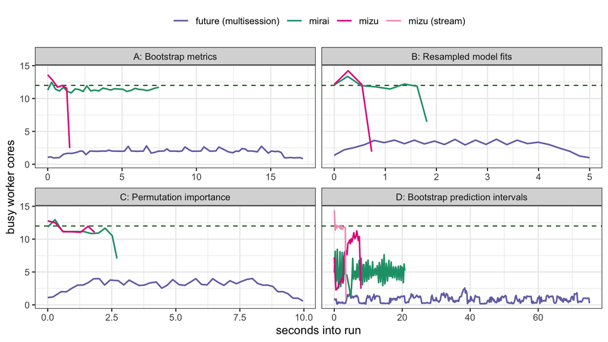

**future makes its workers wait in line.** The main session prepares one chunk per worker and sends the chunks one at a time, so a worker stays idle until its chunk has fully arrived. On workload A, future’s workers average only 1.9 of 12 cores busy (B: 2.9), where mirai and mizu sustain 11.4 and 10.7. This is why future’s speed-ups in A and B fall so far short despite 12 workers.[^9]

**On workload D, mirai’s main session does the heavy lifting.** mirai sends the shared portfolio with every task, so the main session spends the run serializing about 17 GB of payloads while the workers average 5.0 of 12 cores. mizu writes the portfolio once, and its workers sustain 7.3 cores.[^10]

**TipPer-worker detail (13 grids)**

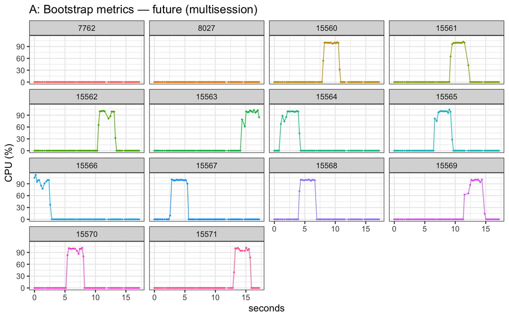

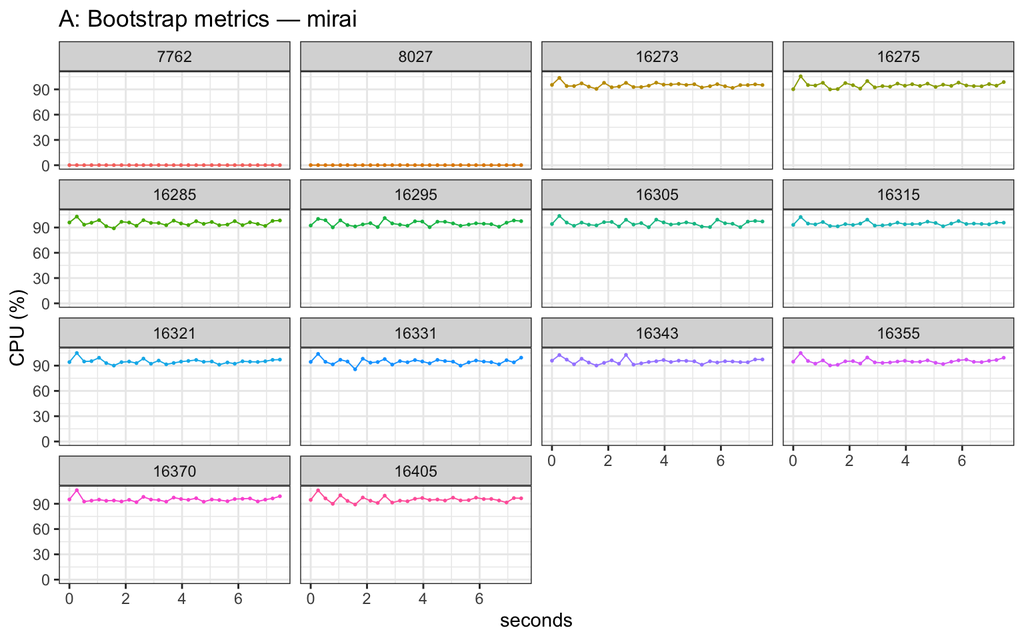

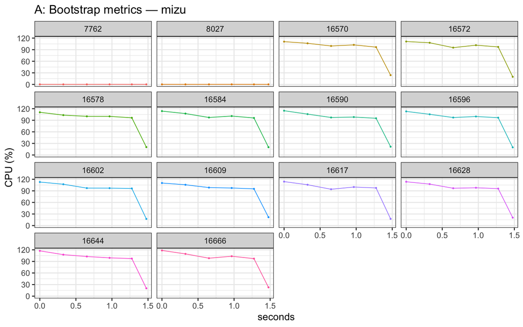

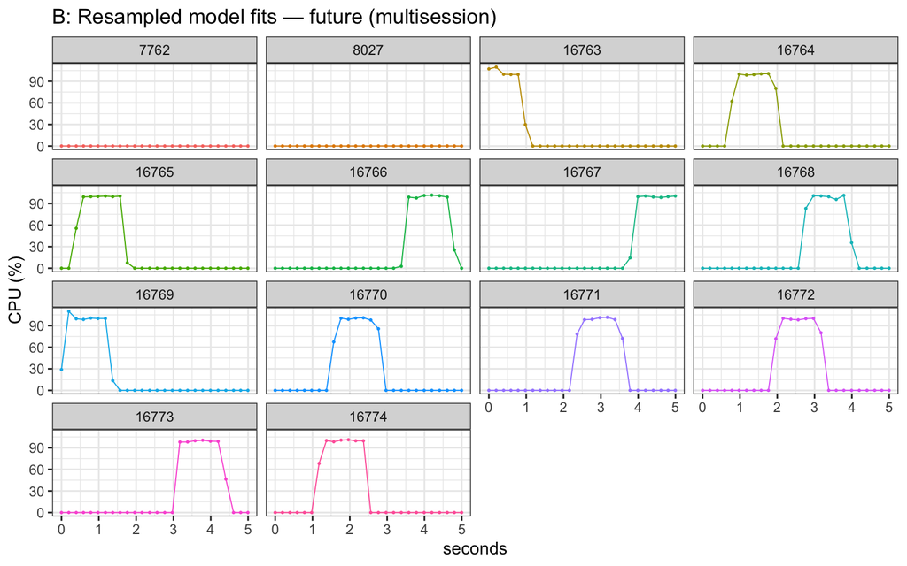

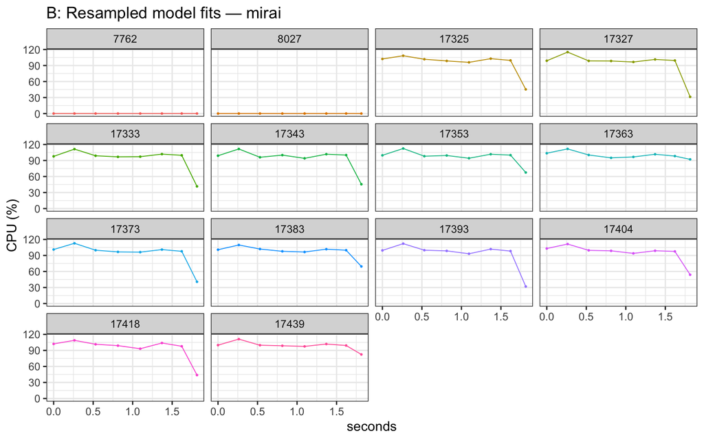

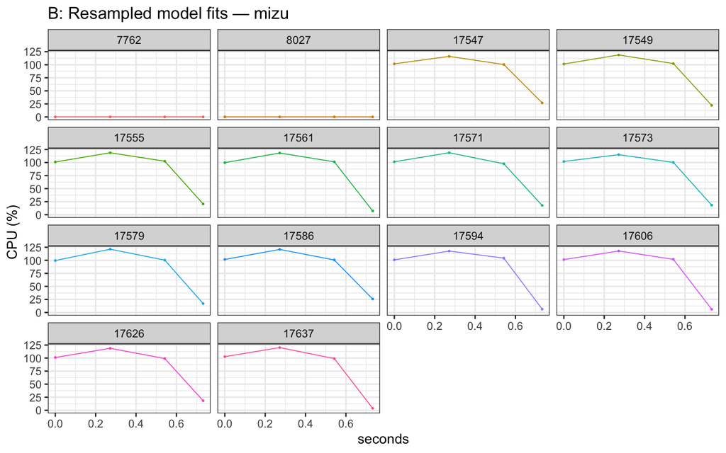

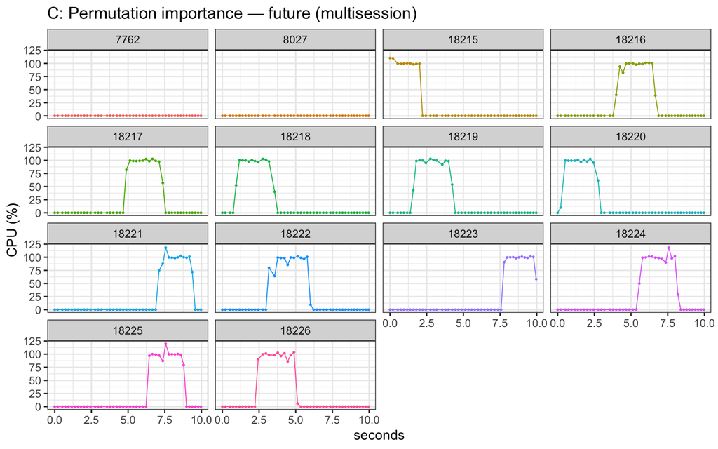

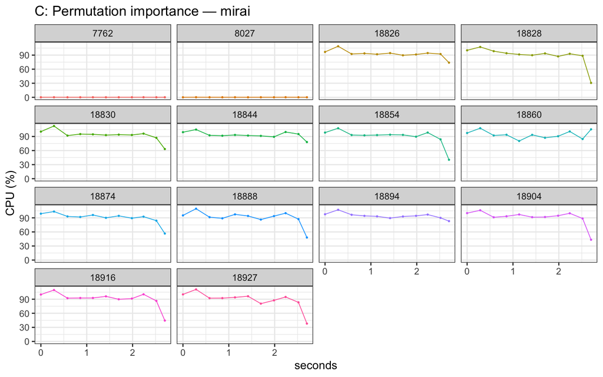

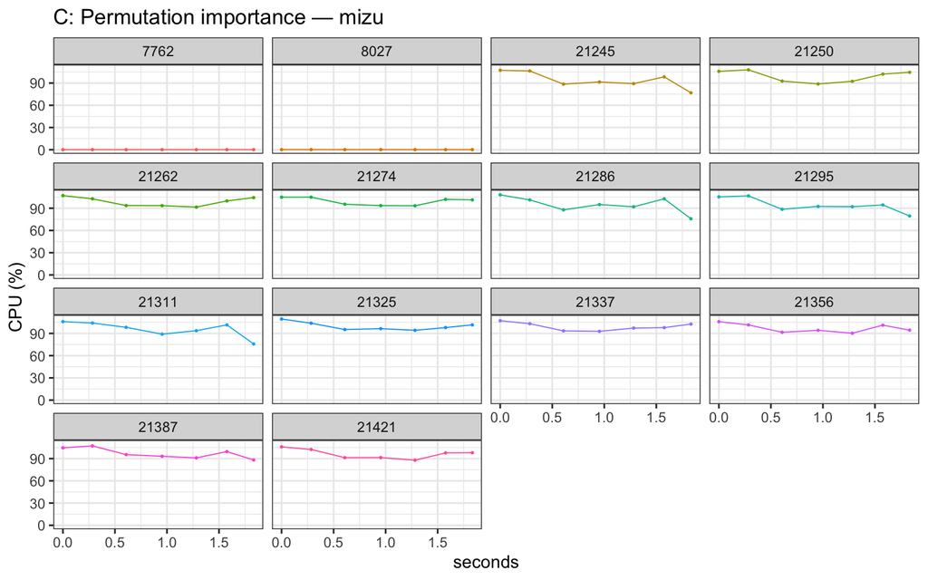

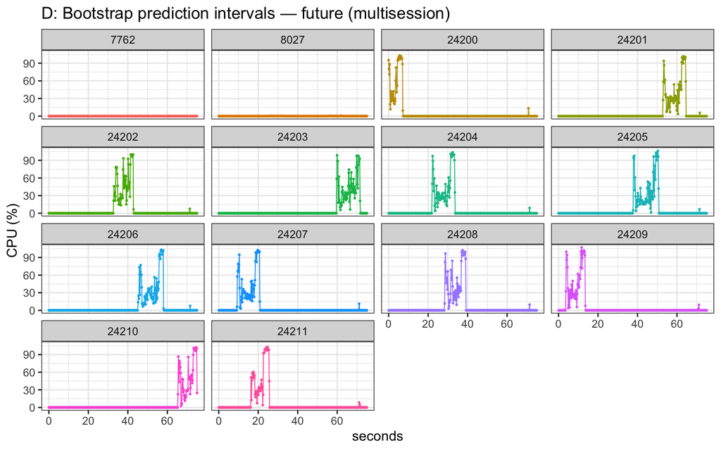

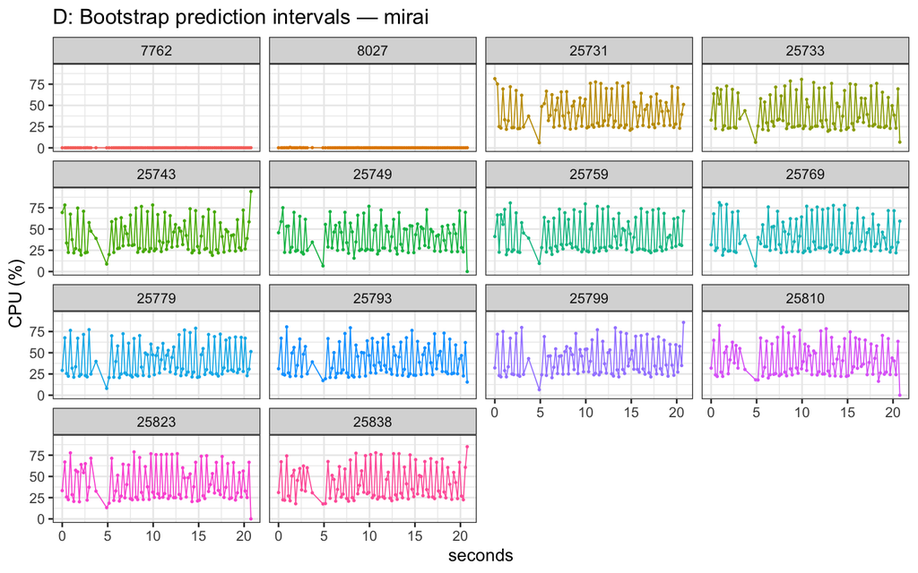

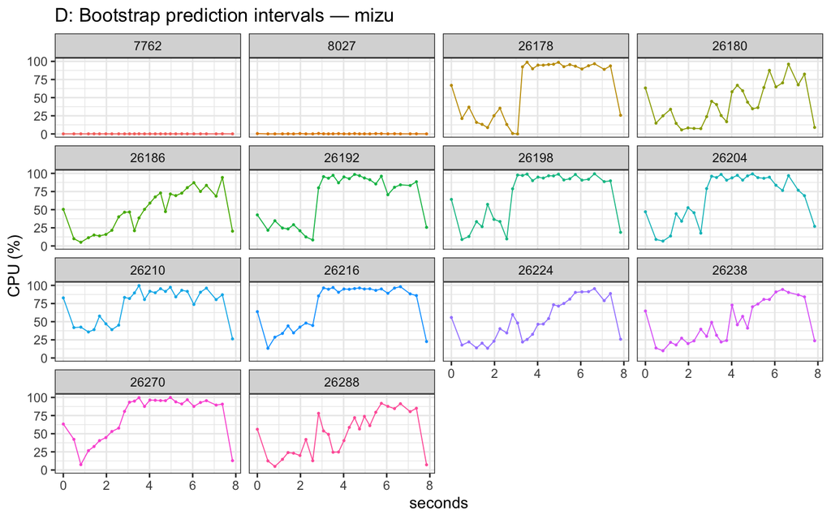

[1 more figures not shown]

## Findings

Per workload, fastest first:

- **A: Bootstrap metrics** (5,000 tasks of ~3 ms). Overhead-bound: there is little compute to split. mizu 6.7× (2.1 s), mirai 1.8×, future 0.7×.
- **B: Resampled model fits** (250 tasks of ~45 ms). mizu 7.9×, mirai 4.0×, future 1.9×.
- **C: Permutation importance** (240 replicates of ~85 ms, ~2.8 MB of data each). mizu 8.1× (2.5 s), mirai 6.4×, future 2.3×.
- **D: Bootstrap prediction intervals** (400 refits, each scoring 250,000 policies and returning 2 MB of predictions). mizu’s streaming map is fastest by far: 7.6× (4.0 s). The standard mizu map reaches 3.2× (9.5 s), mirai 1.4×, and future 0.4×.[^11]

The pattern across A to D: the gap between mizu and the socket-based backends widens as data movement grows relative to compute. Larger task inputs (A, B), a large shared input (D), and large results (D) each add copying that mizu does once or not at all.

## Recommendations

For tidymodels users choosing a backend today:

- **mirai is the safe default.** It is on CRAN, it needs no size-limit settings, and it scales well from about 8 workers up.
- **mizu is the fastest option measured**, on every workload, and by the widest margin exactly where real modeling work moves the most data. It is not yet on CRAN.
- **future** remains a reasonable choice when tasks carry little data. Watch for the chunk dispatch stall on data-heavy workloads, and for the globals size limit on older versions.[^12]

Two habits help on every backend. Strip fitted models to their prediction essentials before sending them to workers.[^13] And set the RNG kind explicitly inside a task function if you compare results across backends.[^14]

## Reproducing

```bash
Rscript benchmark.R                # ~25 min; writes results/*.rds
bash run_all.sh                    # same, but one process per workload with
                                   # per-phase resume (robust to interruption)
BENCH_SWEEP=1 Rscript benchmark.R  # worker-count sweep for B and C;
                                   # writes results/sweep.rds
quarto render benchmark.qmd        # this report
```

Package versions at run time:

| package | version |
| --- | --- |
| future | 1.76.0 |
| future.apply | 1.20.2 |
| mirai | 2.7.3.9000 |
| mizu | 0.0.1.9000 |
| rsample | 1.3.2 |
| yardstick | 1.4.0 |
| parsnip | 1.6.1 |
| workflows | 1.3.0 |
| recipes | 1.4.0 |
| syrup | 0.1.4 |
| parallelly | 1.48.0 |